# X-Ray Pneumonia Deep Learning Calssification Model

## What is Pneumonia and how it looks like on X-Ray pictures?

Pneumonia is a type of respiratory infection that affects the lungs. It can affect people of all ages and be brought on by a wide range of pathogens, such as bacteria, viruses, and fungi.  
The symptoms of pneumonia, which can range in severity from moderate to life-threatening, can include coughing, fever, breathing difficulties, chest pain, and exhaustion.  
Pneumonia might show up as a region of increased density or opacity on an X-ray scan. In contrast to the darker, more translucent regions of normal lung tissue, the damaged lung tissue appears white or grayish-white.  
Depending on the type and intensity of the infection, pneumonia can appear in a variety of ways on a chest X-ray. The affected region may show up in some instances as a small, isolated patch of opacity, while in others it may be more widespread and affect a broader area of the lung.  
The opacity may be interstitial, affecting the tissues surrounding the air sacs in the lungs, or lobar, affecting one or more lung lobes.  
Air bronchograms, which are airways that stand out against the opaque background of the afflicted area, and fluid accumulation in the affected area, which may appear as a fuzzy or hazy area, are further symptoms of pneumonia that may be evident on an X-ray.

# EDA

## dataset structure

**Dataset provided has been already divided into 3 folders:**

- train - data prepared for model training
- val - data prepared for model validation
- test - data prepared for model testing

**Each folder contain 2 subfolders which are:**

- NORMAL - healthy lungs X-Ray
- PNEUMONIA - Lungs X-Ray which are affected by Pneumonia

```python
import matplotlib.pyplot as plt
import matplotlib.pyplot as plt
import pandas as pd
import seaborn as sns
import numpy as np
import time
import cv2
import os
import copy
import torch
import torch.optim as optim
import torch.nn as nn
import torch.nn.functional as F
from torch.utils.data import random_split
from sklearn.model_selection import train_test_split
from torch.utils.data import Dataset, random_split, DataLoader, ConcatDataset
import torchvision
import torchvision.models as models
from torchvision import datasets
from torchvision.utils import make_grid
import torchvision.transforms as transform
from torchvision.datasets import ImageFolder
from tqdm import tqdm
from sklearn.metrics import precision_score, recall_score, f1_score
from sklearn.metrics import confusion_matrix, ConfusionMatrixDisplay
from torch.utils.data import WeightedRandomSampler
```

```python
device = torch.device('cuda:0' if torch.cuda.is_available() else 'cpu')
```

```python
# Data Paths
train_path = "./train/"
val_path = "./val/"
test_path = "./test/"
```

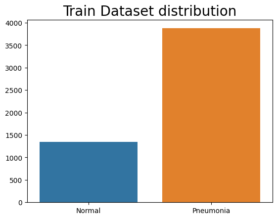

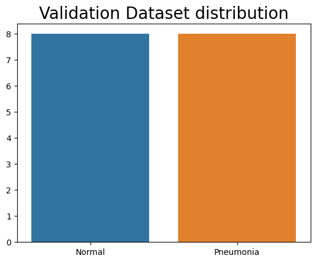

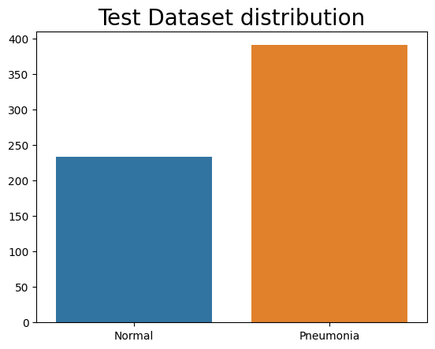

```python
paths = [train_path, val_path, test_path]
samplesize_list=[]

for path in paths:
    samplesize = pd.DataFrame.from_dict(
        {'Normal': [len([os.path.join(path + "NORMAL", filename)
                         for filename in os.listdir(path + "NORMAL")])],
         'Pneumonia': [len([os.path.join(path + "PNEUMONIA", filename)
                            for filename in os.listdir(path + "PNEUMONIA")])]})
    samplesize_list.append(samplesize)

title = ["Train Dataset distribution", "Validation Dataset distribution", "Test Dataset distribution"]
for i in range(0,3):
    g = sns.barplot(data=samplesize_list[i]).set_title(title[i], fontsize=20)
    plt.show()
```

**Normal X-Ray Images**

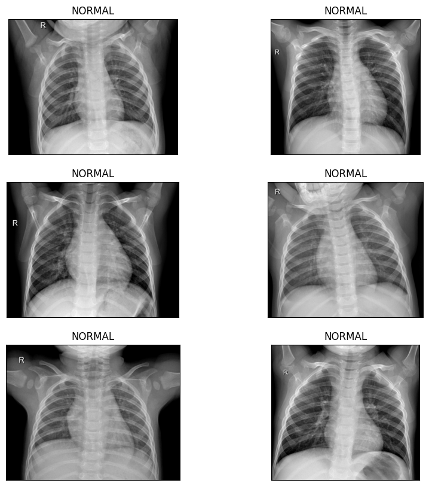

```python
train_normal_list = [os.path.join(train_path + "NORMAL", x) for  x in os.listdir(train_path + "NORMAL")]
train_pneu_list = [os.path.join(train_path + "PNEUMONIA", x) for x in os.listdir(train_path + "PNEUMONIA")]


#Checking images
def show_6images(data, is_pneu=False):
    rnd_idx = np.random.randint(0, len(data), 6)
    plt.figure(figsize = (10,10))
    for idx, rn in enumerate(rnd_idx):
        img = cv2.imread(data[rn], cv2.IMREAD_COLOR)
        plt.subplot(3,2,idx+1)
        if is_pneu:
            plt.title('PNEUMONIA')
        else:
            plt.title('NORMAL')
        plt.tick_params(left = False, bottom = False, labelleft = False, labelbottom = False)
        plt.imshow(img)
    plt.show()

show_6images(train_normal_list)
```

**X-Ray Images with Pneumonia**

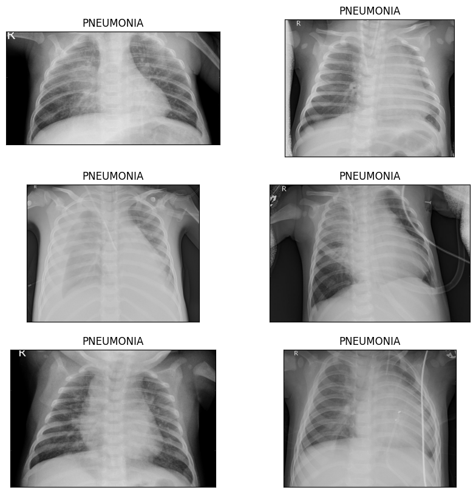

```python
show_6images(train_pneu_list, is_pneu=True)
```

**OBSERVATIONS:**

- Train dataset consists of **1341 Healthy X-rays** and **3875 X-rays with Pneumonia**
- Validation dataset consists of **8 Healthy X-rays** and **8 X-rays with Pneumonia**
- Test dataset consists of **234 Healthy X-rays** and **390 X-rays with Pneumonia**
- Train data is **highly** imbalanced - data augmentation needs to be made in order to balanceout data
- Images are different shape and size - Each image needs to be resized to the same dimensions in order to be able to train the model.(pictures can be slightly zoomed in, because lungs are always in the center on the image)
- In terms of patients, we can observe X-rays of kids as well as adults - chest shape is different which might have positive influence on training (more variety in dataset)

# Research about existing solution

## Data Preparation

Many solutions were using basically the same transformation applied on training dataset, however not many ware taking Training Dataset oversampling to consideration in order to solve imbalance issue.

## Model Architecture

Most of available solutions were using Pre-trained models based on ResNet (Residual Network). It is composed of 34 layers, consisting of convolution layers, pooling layers, and fully connected layers. ResNet34 introduced the concept of residual blocks, where shortcut connections bypass a few layers to mitigate the vanishing gradient problem and enable training of very deep networks. Most of this kind of approaches were achieving accuracy between 81 to 94%

## My Approach

I want to design my own CNN which will be pretty basic in order to make it efficient and not too demanding in terms of computing power. I will make the same transformation as most of the people since it looks like it makes good results, however I will try to design simpler CNN model which will be able to achieve at east 80% of accuracy due to lack of computing power.

# Data Preparation

```python
# set random seed so we get the same sampling every time for reproducibility

random_seed = 100
torch.manual_seed(random_seed);
```

## Data Transformation

**Transformation done on all datasets:**

- Samples reshaped into squares 300 by 300 pixels
- Center cropped to size 256 by 256 in order to remove portions of the image that do not contain any relevant information
- Normalization to ensure that all input features have a similar scale, preventing any particular feature from dominating the learning process, leading to improved convergence and better generalization.

**Additional transformation applied on Train Dataset in order to achieve more diversity in data samples:**

- image horizontal flip applied on 50% of dataset
- random rotation applied on all pictures which means that each image will be rotated between -15 to 15 degrees

```python
transformation = transform.Compose([transform.Resize(size=(300, 300)),
                                            transform.CenterCrop(256),
                                            transform.ToTensor(),
                                            transform.Normalize(mean=[0.485, 0.456, 0.406], std=[0.229, 0.224, 0.225])
                                            ])

train_transform = transform.Compose([transform.Resize(size=(300, 300)),
                                            transform.CenterCrop(256),
                                            transform.RandomHorizontalFlip(p=0.5),
                                            transform.RandomRotation(15),
                                            transform.ToTensor(),
                                            transform.Normalize(mean=[0.485, 0.456, 0.406], std=[0.229, 0.224, 0.225])
                                            ])
```

```python
train_dataset = datasets.ImageFolder(train_path, transform=train_transform)
val_dataset = datasets.ImageFolder(val_path, transform=transformation)
test_dataset = datasets.ImageFolder(test_path, transform=transformation)
```

## Creating Data Loaders and Train Dataset oversampling

**based on previous bar chart, train dataset is highly imbalanced where number of "normal" classified images is significantly smaller than "Pneumonia" class. In order to balance out this dataset, number of "Pneumonia" classified images has been decreased, where "normal" class has been oversampled, in order to "meet in the middle".

```python
targets = [label for _, label in train_dataset]
class_counts = np.bincount(targets)
class_weights = 1.0 / class_counts
weights = [class_weights[label] for label in targets]
sampler = WeightedRandomSampler(weights, len(weights))
```

```python
# Create the data loaders
train_loader = torch.utils.data.DataLoader(train_dataset,sampler=sampler, batch_size=16, shuffle=False, num_workers=12, drop_last=True)
val_loader = torch.utils.data.DataLoader(val_dataset, batch_size=16, shuffle=True, num_workers=12, drop_last=True)
test_loader = torch.utils.data.DataLoader(test_dataset, batch_size=16, shuffle=True, num_workers=12, drop_last=True)
```

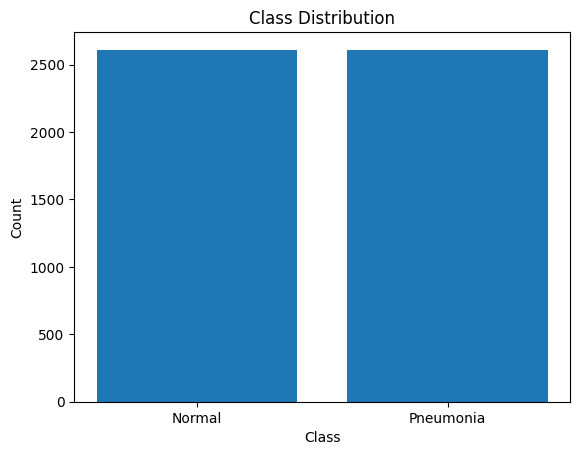

```python
# Calculate the number of samples in each class after oversampling
normal_count = 0
pneumonia_count = 0

for _, labels in train_loader:
    normal_count += torch.sum(labels == 0)
    pneumonia_count += torch.sum(labels == 1)

# Create labels for the classes
class_labels = ["Normal", "Pneumonia"]

# Create counts for the classes
class_counts = [normal_count.item(), pneumonia_count.item()]

# Plot the bar graph
plt.bar(class_labels, class_counts)
plt.xlabel("Class")
plt.ylabel("Count")
plt.title("Class Distribution")
plt.show()
```

```python
class_counts
```

```
[2610, 2606]
```

**Train dataset has been balanced out which results in:**

- "NORMAL" = 2610 samples
- "PNEUMONIA" = 2606 samples

## Batch compairson between Train and Test Datasets

```
Clipping input data to the valid range for imshow with RGB data ([0..1] for floats or [0..255] for integers).
```

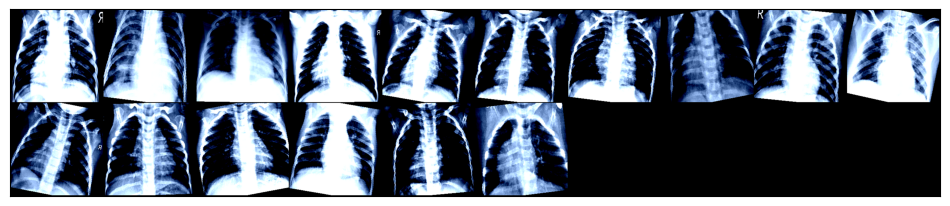

```python
def show_batch(dl):
    for images, labels in dl:
        fig, ax = plt.subplots(figsize=(12, 12))
        ax.set_xticks([]); ax.set_yticks([])
        ax.imshow(make_grid(images[:16], nrow=10).permute(1, 2, 0))
        break

show_batch(train_loader)
```

```
Clipping input data to the valid range for imshow with RGB data ([0..1] for floats or [0..255] for integers).
```

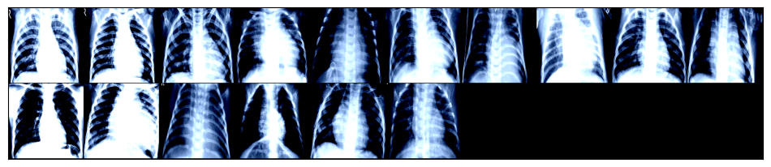

```python
show_batch(test_loader)
```

**OBSERVATION**

- We can clearly see additional transformation applied on Train Dataset in the form of tilted images

# Model Design

```python
def plot_learning_curve(losses, learning_rate, total_epochs, save=False):
    # plot the loss
    plt.figure()
    steps = int(total_epochs / len(losses))
    plt.ylabel('loss')
    plt.xlabel('Iterations ')
    plt.title("Learning rate =" + str(learning_rate))
    plt.plot(np.squeeze(losses))
    locs, labels = plt.xticks()
    plt.xticks(locs[1:-1], tuple(np.array(locs[1:-1], dtype='int')*steps))
    plt.xticks()
    if save:
        plt.savefig('loss_Curve.png', bbox_inches='tight')
    plt.show()
```

```python
# validation loss function
def validation_loss(model, val_loader):
    loss_fn = torch.nn.functional.cross_entropy
    total_loss = 0.0
    model.to(device)
    model.eval()
    with torch.no_grad():
        for inputs, labels in val_loader:
            inputs = inputs.to(device)
            labels = labels.to(device)
            outputs = model(inputs)
            loss = loss_fn(outputs, labels)
            total_loss += loss.item()
    return total_loss / len(val_loader)
```

```python
model = nn.Sequential(
     nn.Conv2d(3, 16, 3, padding=1),
     nn.ReLU(),
     nn.MaxPool2d(2, 2),
     nn.Conv2d(16, 32, 3, padding=1),
     nn.ReLU(),
     nn.MaxPool2d(2, 2),
     nn.Conv2d(32, 64, 3, padding=1),
     nn.ReLU(),
     nn.MaxPool2d(2, 2),
     nn.Flatten(),
     nn.Dropout(0.25),
     nn.Linear(16 * 64 * 64 , 512),
     nn.ReLU(),
     nn.Dropout(0.25),
     nn.Linear(512, 2)
)

model.to(device)
```

```
Sequential(
  (0): Conv2d(3, 16, kernel_size=(3, 3), stride=(1, 1), padding=(1, 1))
  (1): ReLU()
  (2): MaxPool2d(kernel_size=2, stride=2, padding=0, dilation=1, ceil_mode=False)
  (3): Conv2d(16, 32, kernel_size=(3, 3), stride=(1, 1), padding=(1, 1))
  (4): ReLU()
  (5): MaxPool2d(kernel_size=2, stride=2, padding=0, dilation=1, ceil_mode=False)
  (6): Conv2d(32, 64, kernel_size=(3, 3), stride=(1, 1), padding=(1, 1))
  (7): ReLU()
  (8): MaxPool2d(kernel_size=2, stride=2, padding=0, dilation=1, ceil_mode=False)
  (9): Flatten(start_dim=1, end_dim=-1)
  (10): Dropout(p=0.25, inplace=False)
  (11): Linear(in_features=65536, out_features=512, bias=True)
  (12): ReLU()
  (13): Dropout(p=0.25, inplace=False)
  (14): Linear(in_features=512, out_features=2, bias=True)
)
```

## Training

```
Epoch [1/50], Train Loss: 0.2664, Val Loss: 0.8346
```

[figure not shown]

```
Epoch [2/50], Train Loss: 0.1488, Val Loss: 0.8046
```

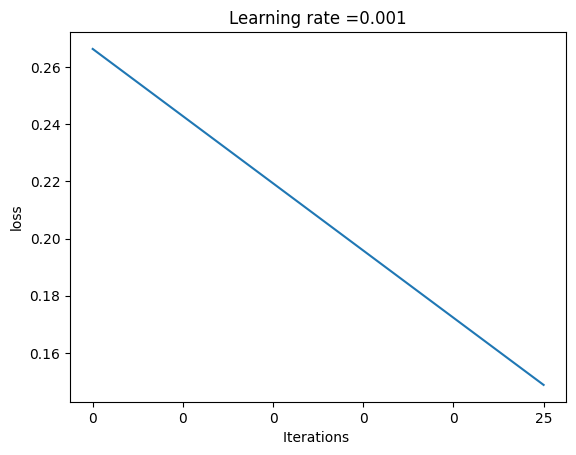

```
Epoch [3/50], Train Loss: 0.1268, Val Loss: 0.2489
```

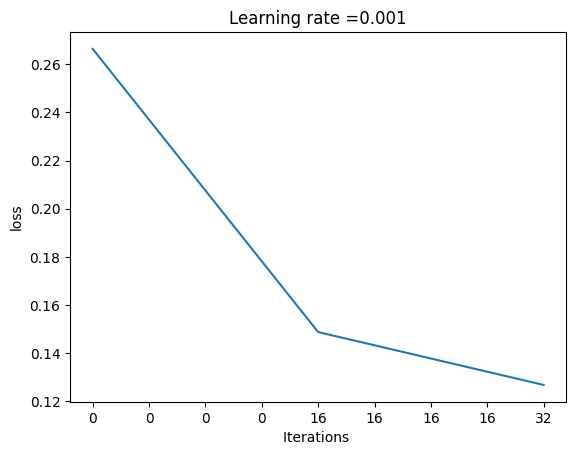

```
Epoch [4/50], Train Loss: 0.1363, Val Loss: 0.4641
```

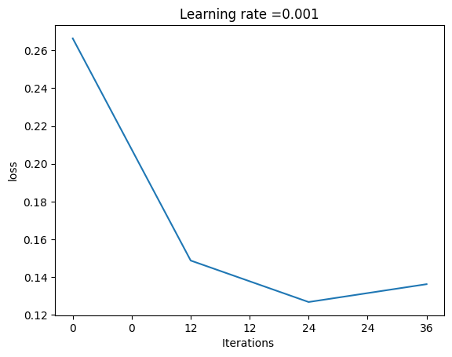

```
Epoch [5/50], Train Loss: 0.1172, Val Loss: 0.3574
```

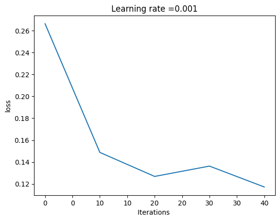

```
Epoch [6/50], Train Loss: 0.0908, Val Loss: 0.6533
```

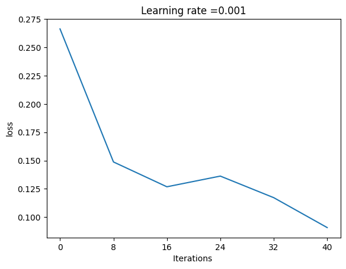

```
Epoch [7/50], Train Loss: 0.1060, Val Loss: 0.5947
```

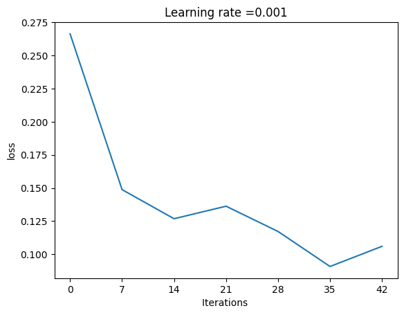

```
Epoch [8/50], Train Loss: 0.1048, Val Loss: 0.4595
```

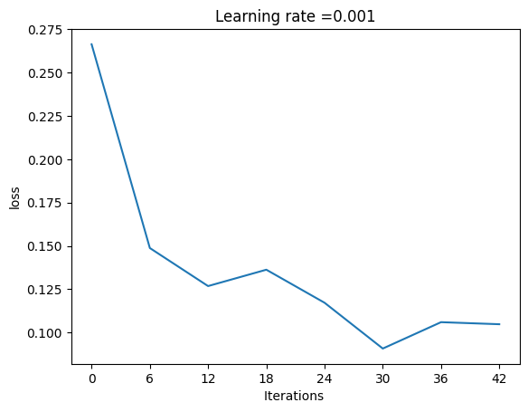

```
Epoch [9/50], Train Loss: 0.0957, Val Loss: 0.4053
```

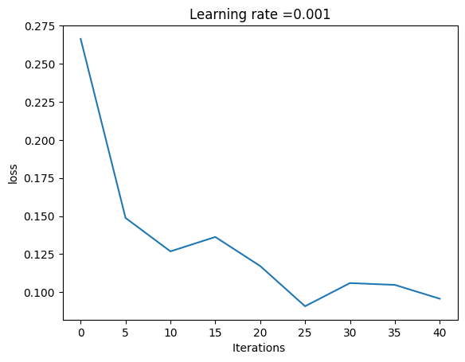

```
Epoch [10/50], Train Loss: 0.0820, Val Loss: 0.2696
```

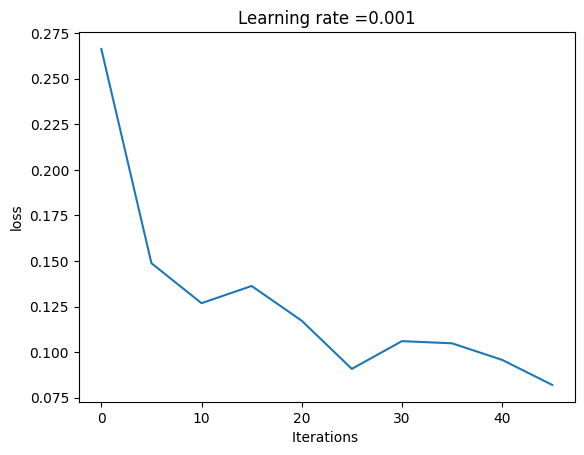

```
Epoch [11/50], Train Loss: 0.0781, Val Loss: 0.3203
```

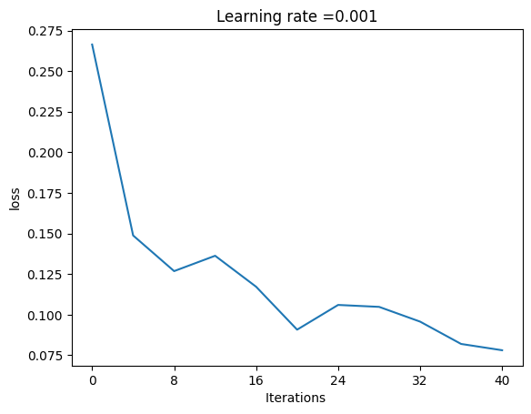

```
Epoch [12/50], Train Loss: 0.0745, Val Loss: 0.4107
```

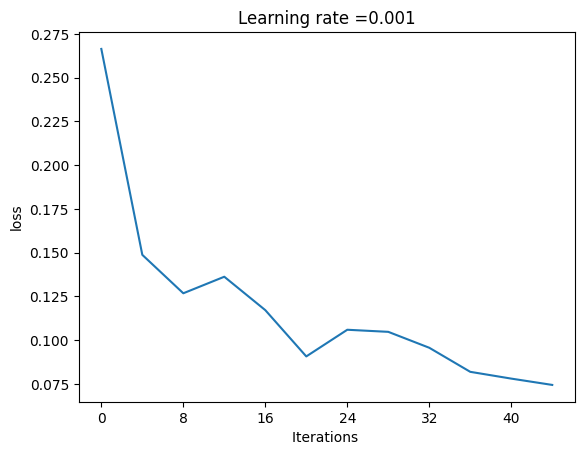

```
Epoch [13/50], Train Loss: 0.0820, Val Loss: 0.3313
```

[38 more figures not shown]

```python
#Hyperparameters
learning_rate = 0.001
num_epochs = 50

optimizer = torch.optim.Adam(model.parameters(), lr=learning_rate)
criterion = nn.CrossEntropyLoss()

train_loss_history = []
val_loss_history = []
losses = []

# Train the model
for epoch in range(num_epochs):
    model.train()
    running_loss = 0.0

    for inputs, labels in train_loader:
        # Move the batch to the GPU if available
        inputs = inputs.to(device)
        labels = labels.to(device)

        # Zero the gradients
        optimizer.zero_grad()

        # Forward pass
        outputs = model(inputs)
        loss = torch.nn.functional.cross_entropy(outputs, labels)

        # Backward pass and optimization
        loss.backward()
        optimizer.step()
        running_loss += loss.item()

    # Print the average loss for the epoch
    val_loss = validation_loss(model, val_loader)
    epoch_loss = running_loss / len(train_loader)
    train_loss_history.append(epoch_loss)
    val_loss_history.append(val_loss)
    losses.append(epoch_loss)
    print(f"Epoch [{epoch+1}/{num_epochs}], Train Loss: {epoch_loss:.4f}, Val Loss: {val_loss:.4f}")
    plot_learning_curve(losses, learning_rate, num_epochs)
```

```python
# Evaluate the model on the test set
predicted_labels = []
true_labels = []
total_loss = 0.0
correct = 0
total = 0

model.eval()
model.to(device)
with torch.no_grad():
    for images, labels in test_loader:
        images = images.to(device)
        labels = labels.to(device)

        outputs = model(images)

        loss = criterion(outputs, labels)
        total_loss += loss.item()

        _, predicted = torch.max(outputs.data, 1)
        correct += (predicted == labels).sum().item()
        total += labels.size(0)

        true_labels.extend(labels.cpu().numpy())
        predicted_labels.extend(predicted.cpu().numpy())

epoch_loss = total_loss / len(test_loader)
epoch_accuracy = correct / total
```

[output not shown]

```python
def plot_metrics(train_loss_history, val_loss_history, test_loss, test_accuracy, true_labels, predicted_labels):
    print(f"Accuracy on the test set: {test_accuracy:.2%}")

    # Calculate precision, recall, and F1 score using the accumulated true labels and predictions
    precision = precision_score(true_labels, predicted_labels)
    recall = recall_score(true_labels, predicted_labels)
    f1 = f1_score(true_labels, predicted_labels)
    print(f"Precision: {precision:.2f}, Recall: {recall:.2f}, F1 score: {f1:.2f}")

    # Calculate the confusion matrix using the accumulated true labels and predictions
    cm = confusion_matrix(true_labels, predicted_labels)

    # Visualize the confusion matrix
    plt.figure()
    disp = ConfusionMatrixDisplay(confusion_matrix=cm, display_labels=["Normal", "Pneumonia"])
    disp.plot()

    # Plot the learning curves
    plt.figure()
    plt.plot(train_loss_history, label='Train Loss')
    plt.plot(val_loss_history, label='Validation Loss')
    plt.xlabel('Epoch')
    plt.ylabel('Loss')
    plt.title('Loss history')
    plt.legend()
    plt.show()
```

```
Accuracy on the test set: 81.73%
Precision: 0.78, Recall: 0.99, F1 score: 0.87
```

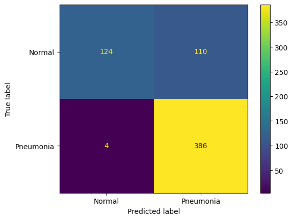

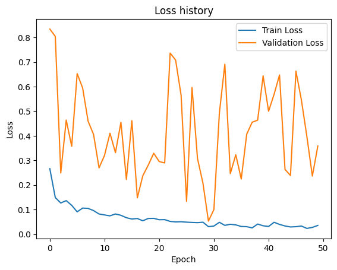

```python
plot_metrics(train_loss_history, val_loss_history, epoch_loss, epoch_accuracy, true_labels, predicted_labels)
```

# Results

**My CNN model was able to achieve:**

- accuracy at 81.73%
- recall at 99%
- F1 score at 0.87
- precision at 78%

**When we have look at confusion matrix we can see that model is struggling with classifying non-Pneumonia samples. It might be caused by less variety of samples which have been just oversampled before. On the other hand, Pneumonia samples were almost perfectly classified with only 4 false negative samples.**

**Validation loss it totally all over the place due to small amount of samples (just 16 samples was provided under validation folder). In order to make validation useful, validation folder needs to include more samples. We could sacrifice some portion of training dataset, but I did not want to do it since training dataset was not too big in terms of clean data without oversampling (just approx. 1400 samples in "NORMAL" class).**